# Final Project

Benjamin Foglia

8/20/2019

## Discussion

For this report, I examined the dataset sales_data.

## Initial Setup

```r
## run important packages and read in data
library(tidyverse)
```

```r
library(tidyr)
library(ggplot2)
library(readr)
library(stringr)
library(dplyr)

Sales_data <- read_csv("E:/BAN 6003/sales_data.csv")
```

## Metadata

**flag** **gender** **education** **house_val** **age_bracket** - *which age bin the person falls in (1=unknown, 2=lowest, 7=highest)* **age_range** - *person’s age range (i.e. >65)* **online** **customer_psy** **marriage** **children** **occupation** **mortgage** **house_own** **region** **car_prob** **fam_income**

## Wrangling

The first thing I wanted to do with the initial dataset was change values like education and mortgage to numerical values. I also split age into 2 columns, one containting the number before the ’_’, and one after. I thought this made it easier to read, and that using the first number would making grouping people together by age easier.

```r
## Education
Sales_data$education <- str_remove_all(Sales_data$education, " <HS")
Sales_data$education <- str_remove_all(Sales_data$education, " HS")
Sales_data$education <- str_remove_all(Sales_data$education, " Some College")
Sales_data$education <- str_remove_all(Sales_data$education, " Bach")
Sales_data$education <- str_remove_all(Sales_data$education, " Grad")

Sales_data$education <- extract_numeric(Sales_data$education)
```

```
## extract_numeric() is deprecated: please use readr::parse_number() instead
```

```r
## Mortgage
Sales_data$mortgage <- str_remove_all(Sales_data$mortgage, "low")
Sales_data$mortgage <- str_remove_all(Sales_data$mortgage, "med")
Sales_data$mortgage <- str_remove_all(Sales_data$mortgage, "high")

Sales_data$mortgage <- extract_numeric(Sales_data$mortgage)
```

```
## extract_numeric() is deprecated: please use readr::parse_number() instead
```

```r
## Age
Sales_data <- separate(Sales_data, age, c("age_bracket", "age_range"), sep = "_")
```

## Transformation

From the original sales_data, I created multiple new data sets by filtering for specific values.

```r
## Data from all who bought the product
buyers_data <- Sales_data %>% filter(flag == "Y")

## Data for all homeowners whose houses had value
house_owners <- Sales_data %>% filter(house_val > 0, house_owner == "Owner")

## House value by region
val_by_region <- Sales_data %>% select(house_val, region)
```

## Functions, Vectors, Iterations

Per Doc B’s request, I have included the function and for loop that categorizes and counts house values by “below average”, “average to expensive”, and “very expensive”.

```r
mean_val <- mean(Sales_data$house_val)
very_high <- 2*sd(Sales_data$house_val) + mean_val

house_expenses <- function(x){
  if (x > very_high) {
    print("Very Expensive")
  } else if (x > mean_val){
    print("Average to Expensive")
  } else {
    print("Below Average")}
}
# Test
house_expenses(1200000)
```

```
## [1] "Very Expensive"
```

```r
## For loop

input <- c(1000, 310000, 1200000)
output <- vector("character", length(input))

for (i in seq_along(input)){
  output[[i]] <- house_expenses(input[[i]])
}
```

```
## [1] "Below Average"
## [1] "Average to Expensive"
## [1] "Very Expensive"
```

```r
input_house_val <- Sales_data$house_val
```

```r
for (i in seq_along(input_house_val)){
  output[[i]] <- house_expenses(input_house_val[[i]])
}
v=0
a=0
b=0

for (i in seq_along(output)){
  if(output[[i]] == "Very Expensive") {v=v+1}
  else if(output[[i]] == "Average to Expensive"){a=a+1}
  else{b=b+1}
}
```

```r
house_results <- c("Very Expensive" = v, "Average to Expensive" = a, "Below Average" = b)
house_results
```

```
##       Very Expensive Average to Expensive        Below Average
##                 1203                12654                26143
```

```r
## most houses are below average value
```

## Visualizations

I focused on a couple of different things for my visualizations. First and foremost, I wanted to see what types of people were buying the product. Secondly, I did some of what Doc B asked for and looked for variations in in house values with respect to other variables.

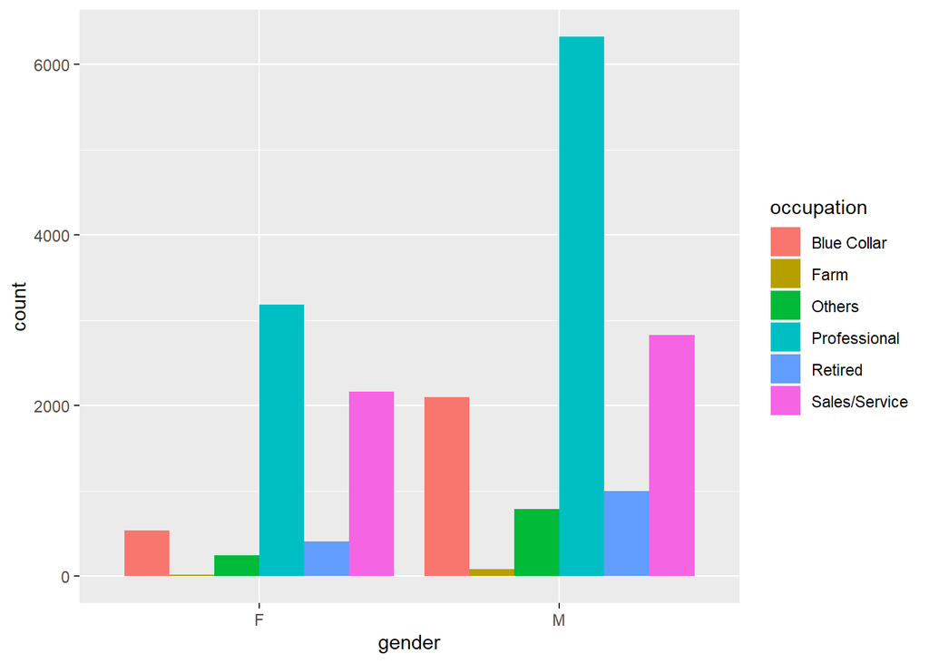

```r
## Using buyers_data, I looked at which genders and professions were buying the product. To simplify, I only used data where the gender of the person was known.
ggplot(buyers_data %>% filter(gender != "U"))+
  geom_bar(aes(x=gender, fill = occupation), position = "dodge")
```

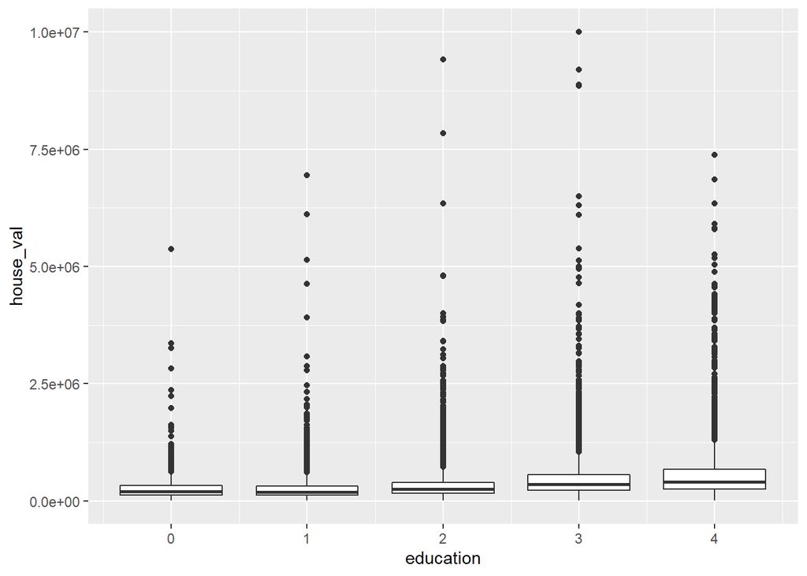

```r
## For Doc B, I created a boxplot to compare education and house value using the house_owner dataset
ggplot(house_owners, aes(x=education, y=house_val))+
  geom_boxplot(aes(group = education))
```

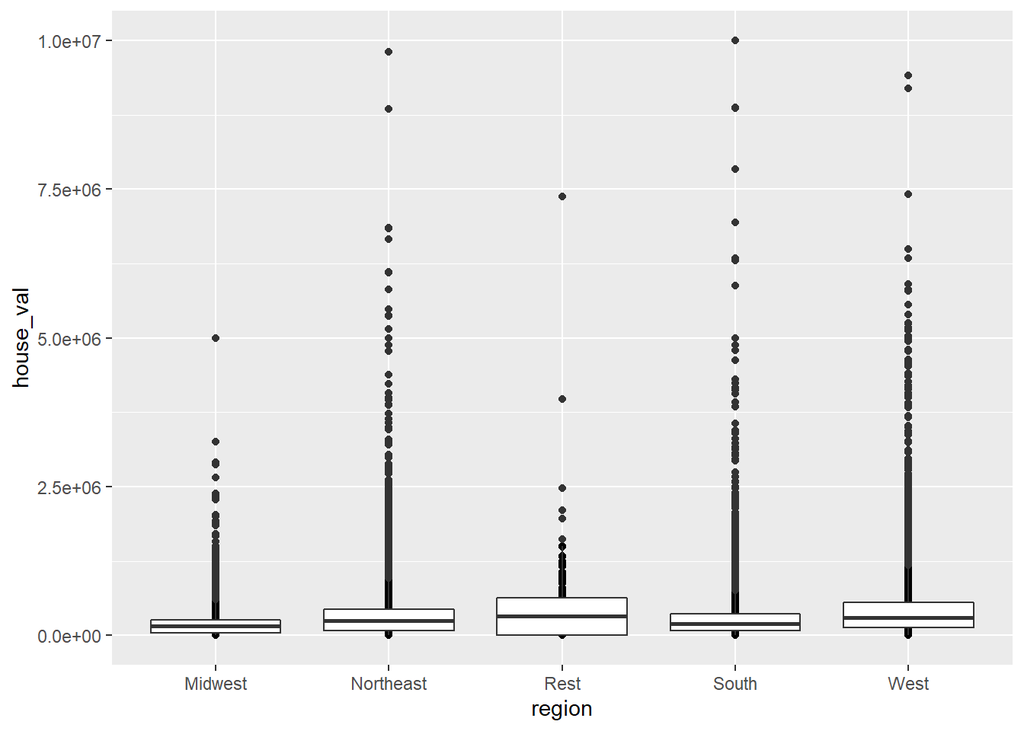

```r
## based on the boxplot, while the most expensive houses are in education groups 2 & 3, there does seem to be evidence suggesting that someone with a higher education level will own a more expensive house.

## Another Boxplot, this time comparing house value by region
ggplot(val_by_region, aes(x=region, y = house_val, group = region))+
  geom_point()+
  geom_boxplot()
```

## Final Notes

I didn’t want to make a second boxplot; I would have much preferred to make a third type of visualization. I tried to spread my val_by_region and have each region be its own variable, but kept getiing errors saying “Each row of output must be identified by a unique combination of keys. Keys are shared for 40000 rows”. I then would have wanted to use the geom_map function to illustrate average price by region in the United States.